# Lab 2 - Basic Signals

*This week, the lab will be an assignment to get familar with some basic DSP and audio in Python. Please complete the following problems.*

```python
import numpy as np
import matplotlib.pyplot as plt
import IPython.display as ipd
from scipy import signal

%matplotlib inline
```

*Remember, you can always use python's help function to learn more about any function or module. For example, see below:*

```python
help(np.arange)
```

```
Help on built-in function arange in module numpy.core.multiarray:

arange(...)
    arange([start,] stop[, step,], dtype=None)

    Return evenly spaced values within a given interval.

    Values are generated within the half-open interval ``[start, stop)``
    (in other words, the interval including `start` but excluding `stop`).
    For integer arguments the function is equivalent to the Python built-in
    `range <http://docs.python.org/lib/built-in-funcs.html>`_ function,
    but returns an ndarray rather than a list.

    When using a non-integer step, such as 0.1, the results will often not
    be consistent.  It is better to use ``linspace`` for these cases.

    Parameters
    ----------
    start : number, optional
        Start of interval.  The interval includes this value.  The default
        start value is 0.
    stop : number
        End of interval.  The interval does not include this value, except
        in some cases where `step` is not an integer and floating point
        round-off affects the length of `out`.
    step : number, optional
        Spacing between values.  For any output `out`, this is the distance
        between two adjacent values, ``out[i+1] - out[i]``.  The default
        step size is 1.  If `step` is specified as a position argument,
        `start` must also be given.
    dtype : dtype
        The type of the output array.  If `dtype` is not given, infer the data
        type from the other input arguments.

    Returns
    -------
    arange : ndarray
        Array of evenly spaced values.

        For floating point arguments, the length of the result is
        ``ceil((stop - start)/step)``.  Because of floating point overflow,
        this rule may result in the last element of `out` being greater
        than `stop`.

    See Also
    --------
    linspace : Evenly spaced numbers with careful handling of endpoints.
    ogrid: Arrays of evenly spaced numbers in N-dimensions.
    mgrid: Grid-shaped arrays of evenly spaced numbers in N-dimensions.

    Examples
    --------
    >>> np.arange(3)
    array([0, 1, 2])
    >>> np.arange(3.0)
    array([ 0.,  1.,  2.])
    >>> np.arange(3,7)
    array([3, 4, 5, 6])
    >>> np.arange(3,7,2)
    array([3, 5])
```

## Problem 1 - Sum of weighted sinusoids

Using the given parameters, create a signal **x** that contains the following sum of sinusoids.

$$ x = \sum_{n=1}^{numFreqs} \frac{\cos( 2 \pi n f0 t)}{n} $$

Let the sampling rate **fs** be 8000Hz, the duration **dur** be 2 seconds, the fundamental frequency **f0** be 200Hz, and the number of frequencies **numFreqs** be 12. Plot the first 20 milliseconds of the time domain signal. Then plot the magnitude spectrum in the frequency domain from 0Hz to the Nyquist frequency. Finally, listen to your signal.

```python
fs = 8000
dur = 2
f0 = 200
numFreqs = 12
```

Hint: You may consider using the following functions

- np.arange()
- np.linspace()
- np.cos()
- np.dot()
- plt.xlim()
- plt.plot()
- np.fft.fft()
- np.fft.fftfreq()
- np.absolute()
- ipd.Audio()

Also, you can always check the dimensions of an array with np.shape(). You can use np.reshape() to change this shape.

## Your Answer:

[interactive chart not shown]

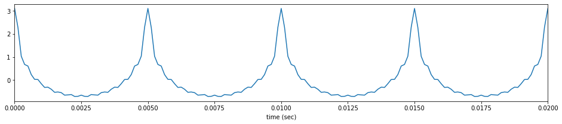

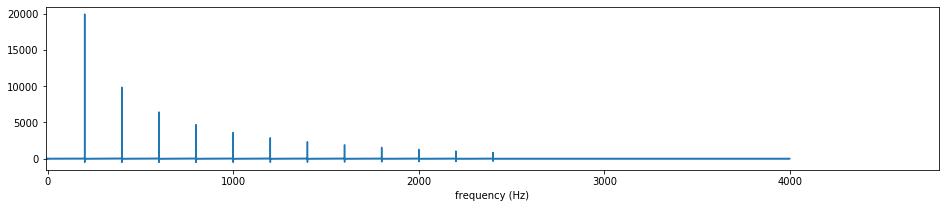

```python
Ts = 1/fs

t = np.linspace(0, dur, int(dur * fs))

x = 0
for n in range(1,numFreqs+1):
    x = x + np.cos(2 * np.pi * n * f0 * t) / n

fft_x = np.fft.fft(x)
fft_freq = np.fft.fftfreq(x.size, d=Ts)

# PLOT ======================================

plt.figure(figsize = (16,3))
plt.xlim(0,0.02)
plt.xlabel("time (sec)")
plt.plot(t,x);

plt.figure(figsize = (16,3))
plt.xlim(-10,2 * n * f0)
plt.xlabel("frequency (Hz)")
plt.plot(fft_freq,fft_x);

ipd.Audio(x,rate = fs)
```

## Problem 2 - Chirp signal

Plot the first 200 ms of the chirp in the time domain. Then plot its magnitude and phase spectra in the frequency domain from 0Hz to the Nyquist frequency. Finally, listen to your chirp signal.

```python
f1 = 500
f2 = 1500
dur = 5
```

Hint: You may consider using the following functions

- np.linspace()
- signal.chirp()
- plt.xlim()
- plt.plot()
- np.fft.fft()
- np.fft.fftfreq()
- np.fft.fftshift()
- np.absolute()
- np.arctan()
- ipd.Audio()

## Your Answer:

[interactive chart not shown]

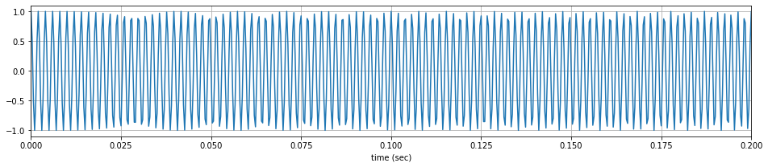

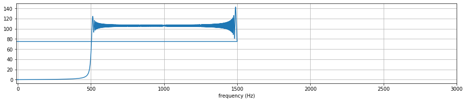

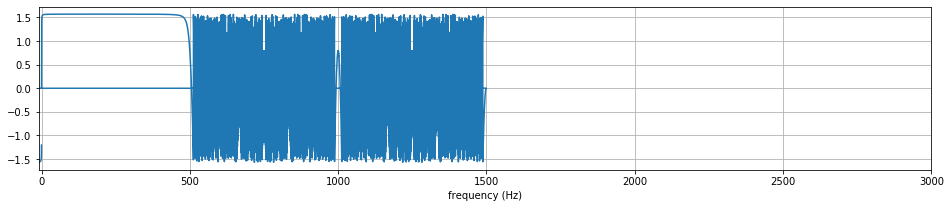

```python
from scipy.signal import chirp

fs = 2 * f2     # sampling rate

t = np.linspace(0, dur, int(dur * fs), endpoint = False)
w = chirp(t, f1, 5, f2, method='linear')

fft_w = np.fft.fft(w)
fft_freq = np.fft.fftfreq(w.size, d=1/fs)

phase = np.arctan(np.imag(fft_w)/np.real(fft_w))

# PLOT ======================================

plt.figure(figsize = (16,3))
plt.xlim(0,0.2)
plt.xlabel("time (sec)")
plt.plot(t,w);
plt.grid(True);

plt.figure(figsize = (16,3))
plt.xlim(-10, fs)
plt.xlabel("frequency (Hz)")
plt.plot(fft_freq,np.abs(fft_w));
plt.grid(True);

plt.figure(figsize = (16,3))
plt.xlim(-10, fs)
plt.xlabel("frequency (Hz)")
plt.plot(fft_freq,phase);
plt.grid(True);


ipd.Audio(w,rate = fs)
```